# Project-6101

Sunny

2024-10-09

# Data

I just select the columns “Median household income (dollars, inflation-adjusted to data file year)”, “Total number of maternal deaths per 100,000 population” and “Total number of drug overdose deaths involving any opioid per 100,000 population”.

```r
data_raw <- read.csv("C:/Users/qluo/Box/6101/project/GROUP-PROJECT-1/Combined_SDOH_2019_2020.csv")
data2 <- subset(data_raw, select = c("ACS_MEDIAN_HH_INC" ,"CDCW_MATERNAL_DTH_RATE", "CDCW_OPIOID_DTH_RATE"))
colnames(data2) <- c("Median_household_income",
                     "Total_number_of_maternal_deaths",
                     "Total_number_of_drug_overdose_deaths")
data2 <- na.omit(data2)
```

```r
summary(data2)
```

```
##  Median_household_income Total_number_of_maternal_deaths
##  Min.   : 39584          Min.   :0.130
##  1st Qu.: 53808          1st Qu.:0.410
##  Median : 62855          Median :0.590
##  Mean   : 67278          Mean   :0.698
##  3rd Qu.: 76997          3rd Qu.:0.840
##  Max.   :130890          Max.   :2.560
##  Total_number_of_drug_overdose_deaths
##  Min.   :  1.24
##  1st Qu.:  8.29
##  Median : 15.04
##  Mean   : 18.07
##  3rd Qu.: 23.84
##  Max.   :102.78
```

# EDA

First, the histograms.

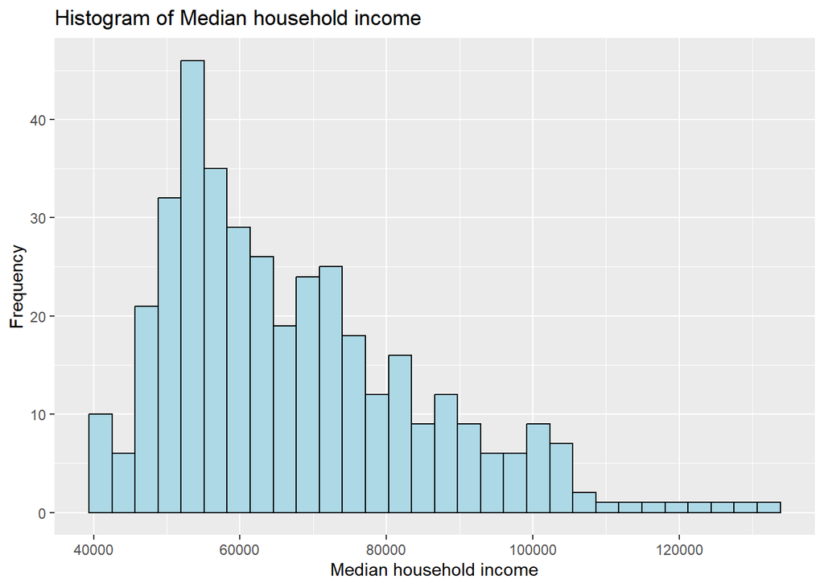

```r
ggplot( data=data2, aes(Median_household_income))+
  geom_histogram(binwith=5000, col="black", fill="lightblue")+
  labs(x="Median household income",
       y= "Frequency",
       title="Histogram of Median household income")
```

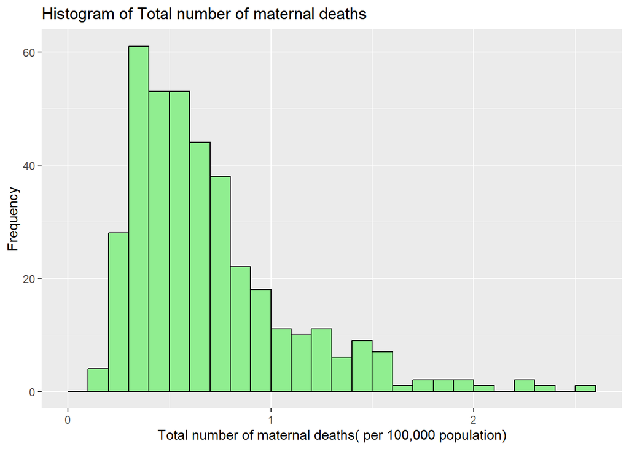

```r
ggplot(data=data2,aes(Total_number_of_maternal_deaths))+
  geom_histogram(breaks=seq(0,2.6,by=.1),
                 col="black",
                 fill="lightgreen")+
  labs(x="Total number of maternal deaths( per 100,000 population)",
       y="Frequency",
       title="Histogram of Total number of maternal deaths")
```

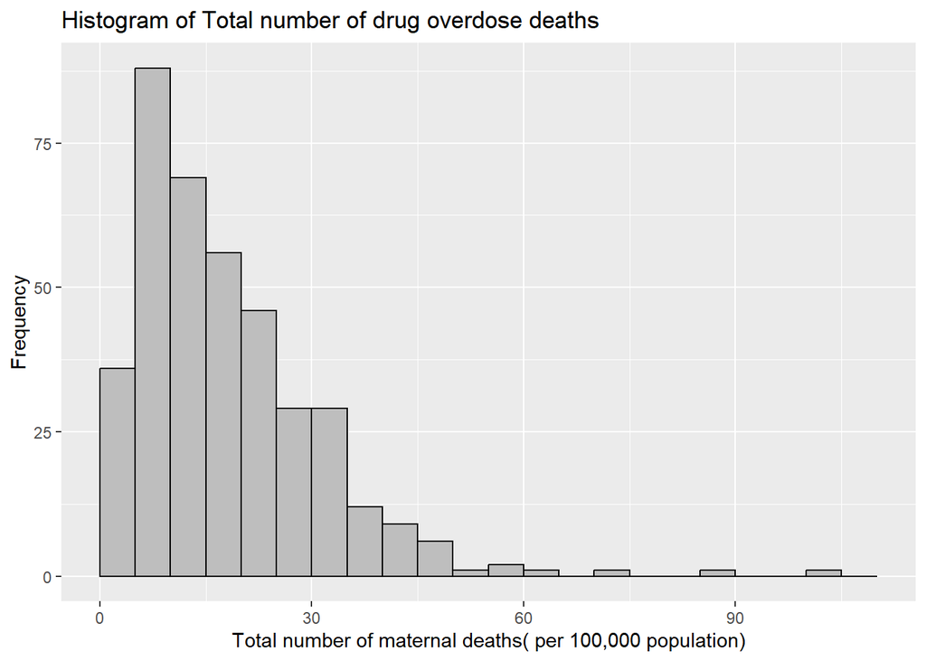

```r
ggplot(data=data2,aes(Total_number_of_drug_overdose_deaths))+
  geom_histogram(breaks=seq(0,110,by=5),
                 col="black",
                 fill="grey")+
  labs(x="Total number of maternal deaths( per 100,000 population)",
       y="Frequency",
       title="Histogram of Total number of drug overdose deaths")
```

Second, the Q-Q plot:

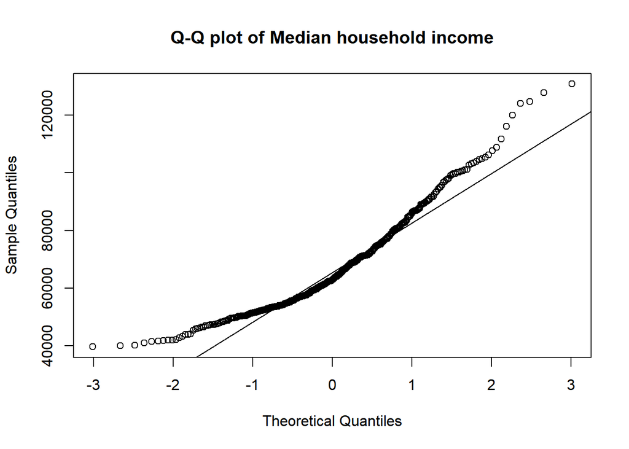

```r
qqnorm(data2$Median_household_income,main="Q-Q plot of Median household income")
qqline(data2$Median_household_income)
```

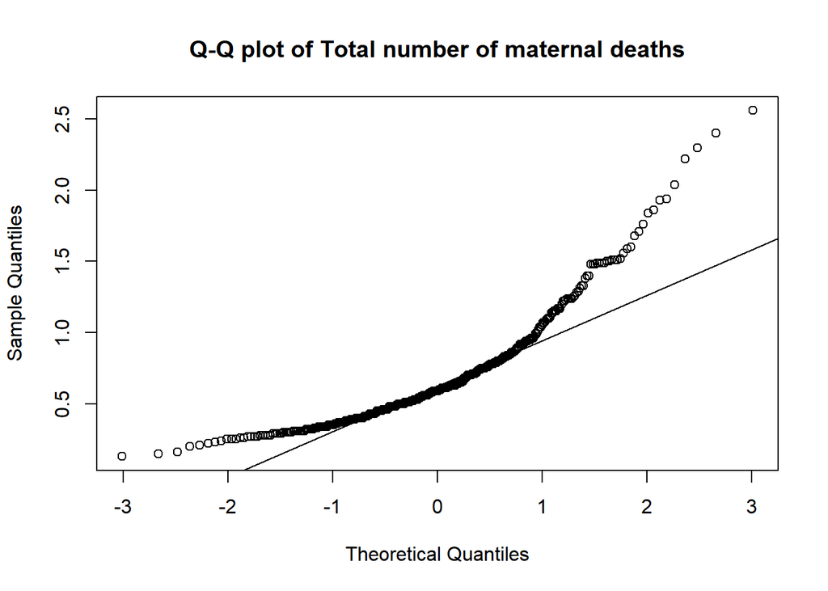

```r
qqnorm(data2$Total_number_of_maternal_deaths,main="Q-Q plot of Total number of maternal deaths")
qqline(data2$Total_number_of_maternal_deaths)
```

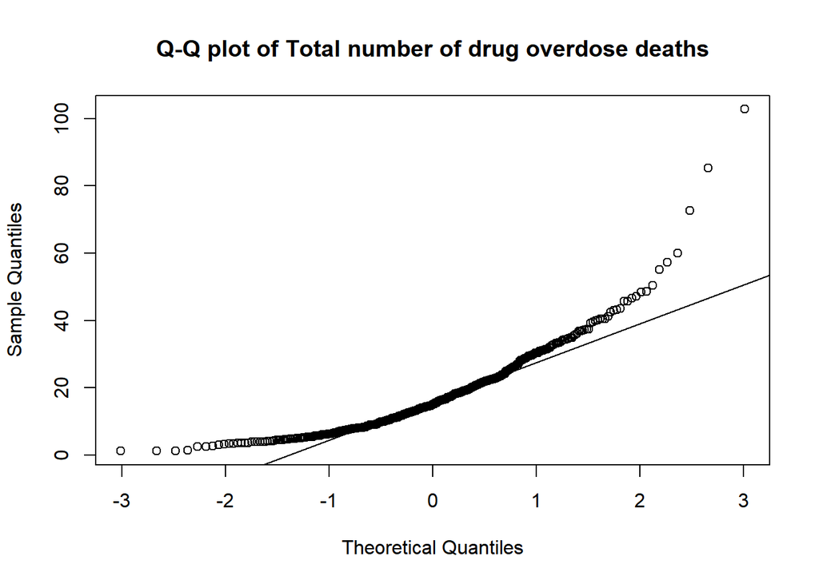

```r
qqnorm(data2$Total_number_of_drug_overdose_deaths,main="Q-Q plot of Total number of drug overdose deaths")
qqline(data2$Total_number_of_drug_overdose_deaths)
```

Now, boxplots.

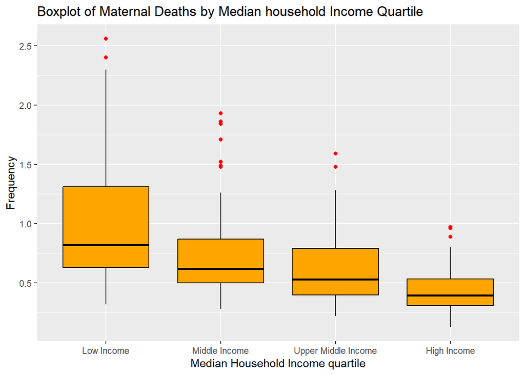

```r
data2$Income_quartile <- ntile(data2$Median_household_income,4)
data2$Income_label <- case_when(
  data2$Income_quartile==1 ~ "Low Income",
  data2$Income_quartile==2 ~ "Middle Income",
  data2$Income_quartile==3 ~ "Upper Middle Income",
  data2$Income_quartile==4 ~ "High Income"
)
data2$Income_label <- factor(data2$Income_label,
                             level=c("Low Income", "Middle Income", "Upper Middle Income", "High Income"))
ggplot(data2,aes(x=Income_label,
                 y=Total_number_of_maternal_deaths))+
  geom_boxplot(col="black", fill="orange",outlier.color = "red")+
  labs(x="Median Household Income quartile",
       y= "Frequency",
       title="Boxplot of Maternal Deaths by Median household Income Quartile")
```

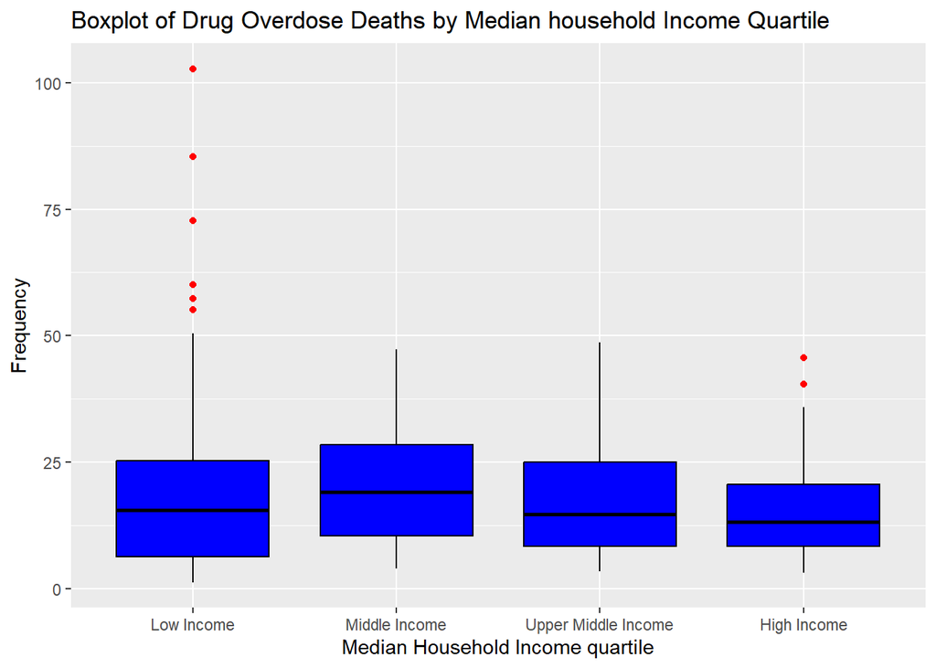

```r
ggplot(data2, aes(x=Income_label,
                  y=Total_number_of_drug_overdose_deaths))+
  geom_boxplot(col="black",fill="blue",outlier.color = "red")+
  labs(x="Median Household Income quartile",
       y= "Frequency",
       title="Boxplot of Drug Overdose Deaths by Median household Income Quartile")
```

The total number of maternal deaths between different income group are different but the pattern in the number of drug overdose deaths is not that clear from the boxplots.

# ANOVA Test

Let’s see if the Total number of maternal deaths per 100,000 population and Total number of drug overdose deaths per 100,000 population are different among different Income groups.

```r
anova_maternal_deaths <- aov(Total_number_of_maternal_deaths ~ Income_label, data=data2)
anova_drug_overdose_deaths <- aov(Total_number_of_drug_overdose_deaths ~ Income_label, data=data2)
xkabledply(anova_maternal_deaths)
```

Model: Total_number_of_maternal_deaths ~ Income_label

|  | Df | Sum Sq | Mean Sq | F value | Pr(>F) |
| --- | --- | --- | --- | --- | --- |
| Income_label | 3 | 15.762 | 5.2540 | 43.872 | 0 |
| Residuals | 383 | 45.867 | 0.1198 | NA | NA |

```r
xkabledply(anova_drug_overdose_deaths)
```

Model: Total_number_of_drug_overdose_deaths ~ Income_label

|  | Df | Sum Sq | Mean Sq | F value | Pr(>F) |
| --- | --- | --- | --- | --- | --- |
| Income_label | 3 | 1738.3 | 579.44 | 3.5309 | 0.015 |
| Residuals | 383 | 62852.4 | 164.11 | NA | NA |

From the above ANOVA tests, both the total number of maternal deaths and drug overdose deaths are not all the same among different income groups. Let’s do Post-hoc Tukey HSD to see which groups are different from others.

## Post-hoc Tukey HSD

```r
tukey_maternal_deaths <- TukeyHSD(anova_maternal_deaths)
tukey_drug_overdose_deaths <- TukeyHSD(anova_drug_overdose_deaths)
tukey_maternal_deaths
```

```
##   Tukey multiple comparisons of means
##     95% family-wise confidence level
##
## Fit: aov(formula = Total_number_of_maternal_deaths ~ Income_label, data = data2)
##
## $Income_label
##                                       diff      lwr         upr   p adj
## Middle Income-Low Income          -0.24825 -0.37647 -0.12002714 0.00001
## Upper Middle Income-Low Income    -0.37629 -0.50451 -0.24806837 0.00000
## High Income-Low Income            -0.55456 -0.68312 -0.42601024 0.00000
## Upper Middle Income-Middle Income -0.12804 -0.25626  0.00017905 0.05047
## High Income-Middle Income         -0.30632 -0.43487 -0.17776282 0.00000
## High Income-Upper Middle Income   -0.17828 -0.30683 -0.04972158 0.00220
```

```r
tukey_drug_overdose_deaths
```

```
##   Tukey multiple comparisons of means
##     95% family-wise confidence level
##
## Fit: aov(formula = Total_number_of_drug_overdose_deaths ~ Income_label, data = data2)
##
## $Income_label
##                                      diff      lwr      upr   p adj
## Middle Income-Low Income           1.1445  -3.6019  5.89098 0.92493
## Upper Middle Income-Low Income    -1.8914  -6.6379  2.85500 0.73298
## High Income-Low Income            -4.4636  -9.2224  0.29514 0.07497
## Upper Middle Income-Middle Income -3.0360  -7.7824  1.71046 0.35165
## High Income-Middle Income         -5.6082 -10.3670 -0.84939 0.01339
## High Income-Upper Middle Income   -2.5722  -7.3310  2.18659 0.50341
```

From the Post-hoc Tukey HSD, the total number of maternal deaths of all the groups are different from others except the Upper Middle Income and Middle Income at 5% significance level. However, only the High Income and Middle Income are different in the total number of drug overdose deaths at the 5% significance level.

Let’s have a look at the correlation coefficients between these variables.

# Correlation Matrix

```r
#install.packages("corrplot")
library("corrplot")
cor_matrix <- cor(data2[,c("Median_household_income","Total_number_of_maternal_deaths",
                           "Total_number_of_drug_overdose_deaths")])
cor_matrix
```

```
##                                      Median_household_income
## Median_household_income                              1.00000
## Total_number_of_maternal_deaths                     -0.50518
## Total_number_of_drug_overdose_deaths                -0.13960
##                                      Total_number_of_maternal_deaths
## Median_household_income                                     -0.50518
## Total_number_of_maternal_deaths                              1.00000
## Total_number_of_drug_overdose_deaths                         0.12869
##                                      Total_number_of_drug_overdose_deaths
## Median_household_income                                          -0.13960
## Total_number_of_maternal_deaths                                   0.12869
## Total_number_of_drug_overdose_deaths                              1.00000
```

The correlation coefficient between income and maternal death is -0.5052, suggesting the negative relationship between the two variables.